# Linear Regression - Part 1

Introduction

author

14/03/2022

# Introduction to Linear Regression

Consider the following simulated data:

```r
library(tidyverse)
library(modelr)
```

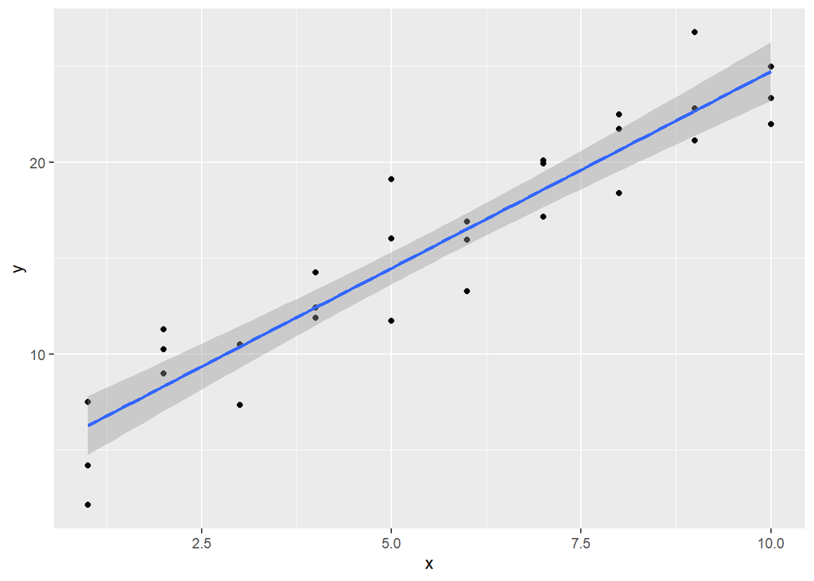

```r
ggplot(sim1, aes(x=x, y=y)) +
  geom_point() +
  geom_smooth(method="lm")
```

Fit a simple linear model to it:

```r
fit <- lm(y ~ x, data=sim1)
```

- `x` is the **predictor** or **explanatory** variable
- `y` is the **response** variable

In R, we can specify a model using the formula interface: `y ~ x`

We can put transformations directly in the formula, and specify more complex models:

- `y ~ x1 + x2 + x3`
- `log(y) ~ x1 + x2 + x3`

A linear regression model is fit by minimizing the sum of squared errors:

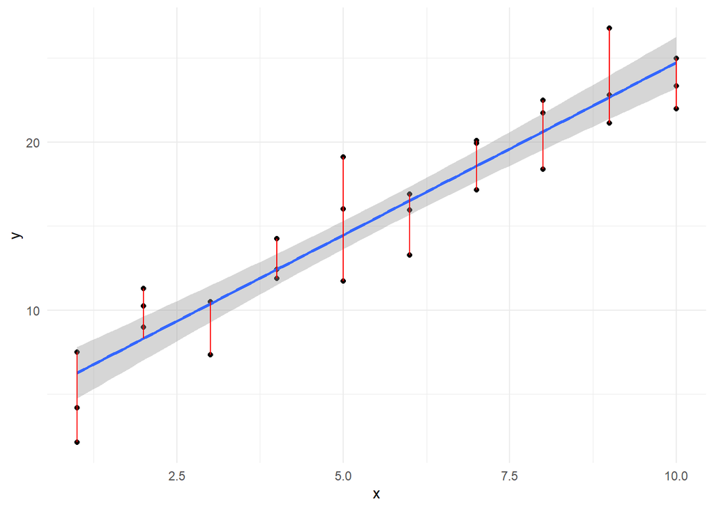

```r
sim1 %>%
  add_predictions(fit) %>%
  ggplot(aes(x=x, y=y)) +
  geom_point() +
  geom_smooth(method="lm") +
  geom_segment(aes(xend=x, yend=pred), color="red") +
  theme_minimal()
```

In linear regression, the errors are also called residuals:

- `resid = y_obs - y_pred`

Positive residuals indicate under-prediction.

Negative residuals indicate over-prediction.

## Extract model parameters and predicted values

```r
coef(fit) # get parameters estimates
```

```
## (Intercept)           x
##    4.220822    2.051533
```

```r
fitted(fit) # get predicted values
```

```
##         1         2         3         4         5         6         7         8
##  6.272355  6.272355  6.272355  8.323888  8.323888  8.323888 10.375421 10.375421
##         9        10        11        12        13        14        15        16
## 10.375421 12.426954 12.426954 12.426954 14.478487 14.478487 14.478487 16.530020
##        17        18        19        20        21        22        23        24
## 16.530020 16.530020 18.581553 18.581553 18.581553 20.633087 20.633087 20.633087
##        25        26        27        28        29        30
## 22.684620 22.684620 22.684620 24.736153 24.736153 24.736153
```

## Extract residuals and number of observations

```r
resid(fit) # get residuals (error terms)
```

```
##            1            2            3            4            5            6
## -2.072442018  1.238279125 -4.146882207  0.664969362  1.919217378  2.972935148
##            7            8            9           10           11           12
## -3.019056466  0.129928252  0.136179642  0.007634878 -0.534352991  1.831009860
##           13           14           15           16           17           18
##  4.651562487 -2.740466108  1.546366596 -3.256043368 -0.574045413  0.364775796
##           19           20           21           22           23           24
##  1.504439222 -1.409703118  1.354755377  1.092815968 -2.242173633  1.842466099
##           25           26           27           28           29           30
##  4.092390235  0.120490168 -1.556314330  0.231946675 -1.389730610 -2.760952005
```

```r
nobs(fit) # get number of observations
```

```
## [1] 30
```

## `modelr` versus `stats`

The `stats` package is distributed with all default R installations. It includes functions such as:

- `lm`: fit linear models
- `glm`: fit generalized linear models
- `fitted`: get predicted values
- `resid`: get residuals

The `modelr` package is part of the `tidyverse` (but is not loaded automatically with `library(tidyverse)`), and includes some convenience functions that make it easier to work with models with the `%>%` operator. A few notable functions include:

- `add_predictions`: adds predicted values to a dataset
- `add_residuals`: adds residuals to a dataset
- `resample_partition:` split data into testing and training sets
- `crossv_kfold`: split data into `k` partitions for cross-validation

# Example: Diamonds

Let’s build a linear regression model using subset of the `diamonds` dataset:

```r
set.seed(1)
diamonds10k <- diamonds %>%
  sample_n(10000) %>%
  mutate(cut_ord = cut,
         color_ord = forcats::fct_relevel(color, rev(levels(color))),
         clarity_ord = clarity,
         cut = as.character(cut_ord),
         color = as.character(color_ord),
         clarity = as.character(clarity_ord))
```

Above, we make some minor adjustments, to make the categorical variables nominal rather than ordinal, because R handles ordinal variables specially in linear regression.

For simplicity’s sake, we will treat `cut`, `color`, and `clarity` as nominal.

# Building a linear regression model

## Plotting a relationship

First we should plot a relationship, and assess whether it’s linear or not:

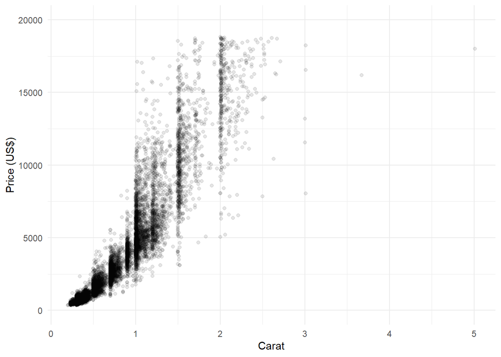

```r
ggplot(diamonds10k, aes(x=carat, y=price)) +
  geom_point(alpha=0.1) +
  coord_cartesian(ylim=c(0,20000)) +
  labs(x="Carat", y="Price (US$)") +
  theme_minimal()
```

Is it linear?

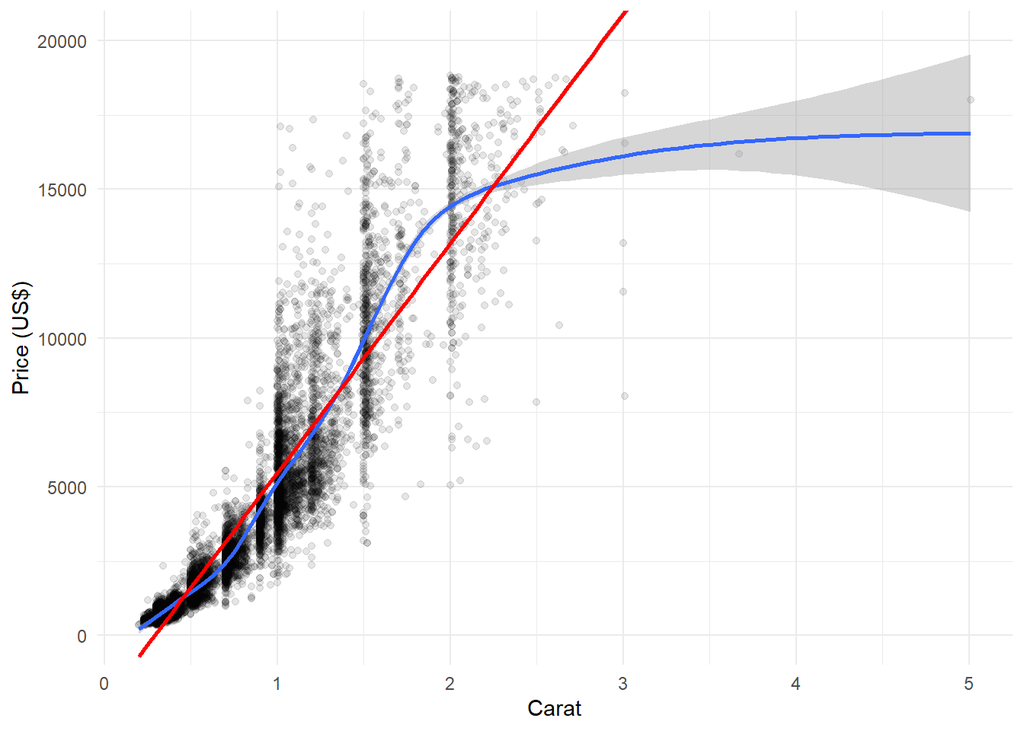

```r
ggplot(diamonds10k, aes(x=carat, y=price)) +
  geom_point(alpha=0.1) +
  geom_smooth() +
  geom_smooth(method="lm", color="red") +
  coord_cartesian(ylim=c(0, 20000)) +
  labs(x="Carat", y="Price (US$)") +
  theme_minimal()
```

No, so we must make use of transformations if we want to use linear regression.

## Log transformations

Log transformations on the response variable are useful for relationships that appear exponential.

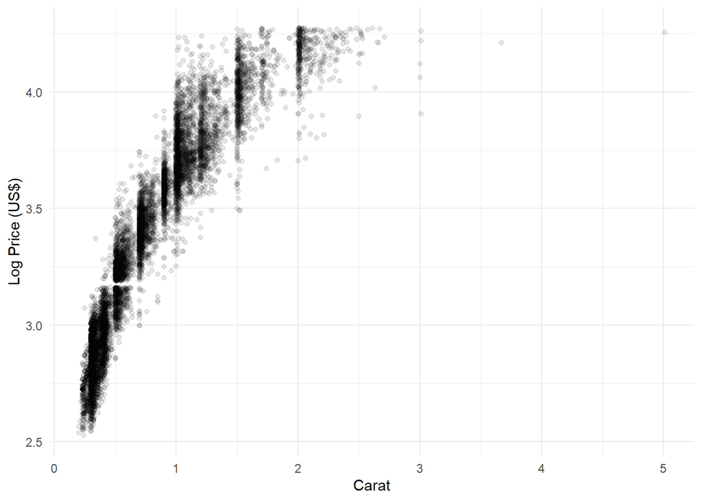

```r
ggplot(diamonds10k, aes(x=carat, y=log10(price))) +
  geom_point(alpha=0.1) +
  labs(x="Carat", y="Log Price (US$)") +
  theme_minimal()
```

This doesn’t quite get us there though.

## Log-log transformations

If we flip the coordinates, we can see it may make sense to log-transform `carat` as well.

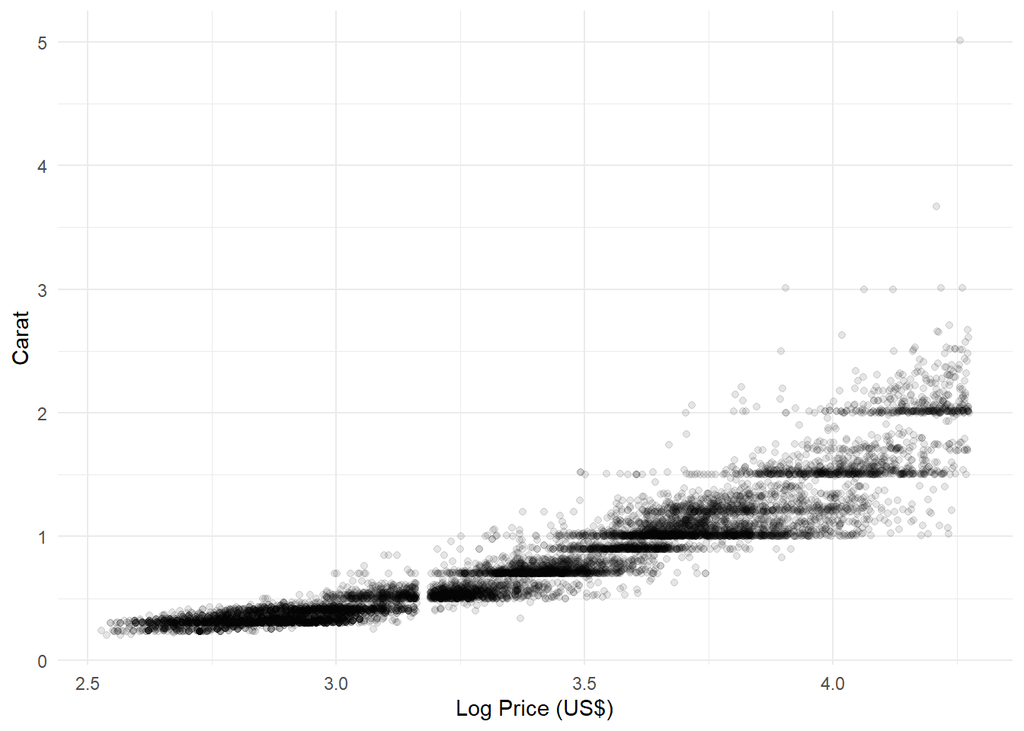

```r
ggplot(diamonds10k, aes(x=carat, y=log10(price))) +
  geom_point(alpha=0.1) +
  labs(x="Carat", y="Log Price (US$)") +
  coord_flip() +
  theme_minimal()
```

Let’s try log-transforming both variables:

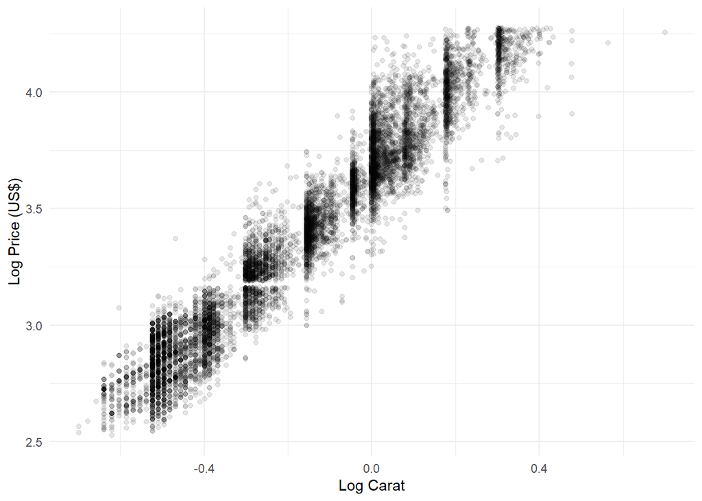

```r
ggplot(diamonds10k, aes(x=log10(carat), y=log10(price))) +
  geom_point(alpha=0.1) +
  labs(x="Log Carat", y="Log Price (US$)") +
  theme_minimal()
```

This looks good:

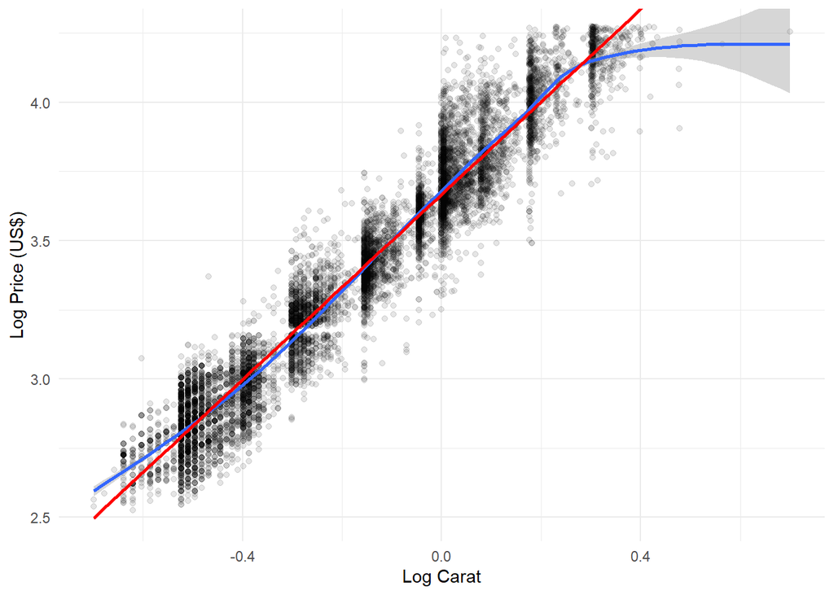

```r
ggplot(diamonds10k, aes(x=log10(carat), y=log10(price))) +
  geom_point(alpha=0.1) +
  geom_smooth() +
  geom_smooth(method="lm", color="red") +
  coord_cartesian(ylim=c(2.5, 4.25)) +
  labs(x="Log Carat", y="Log Price (US$)") +
  theme_minimal()
```

## Visualizing log transformations

Log transformations have the effect of linearizing approximatley exponential relationships, and making right-skew data more symmetric.

Price:

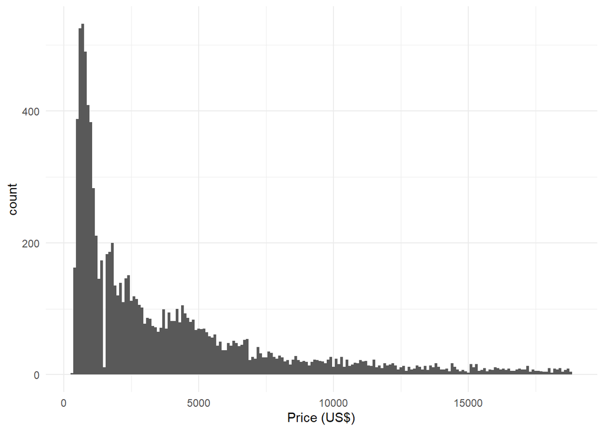

```r
ggplot(diamonds10k, aes(x=price)) +
  geom_histogram(binwidth=100) +
  labs(x="Price (US$)") +
  theme_minimal()
```

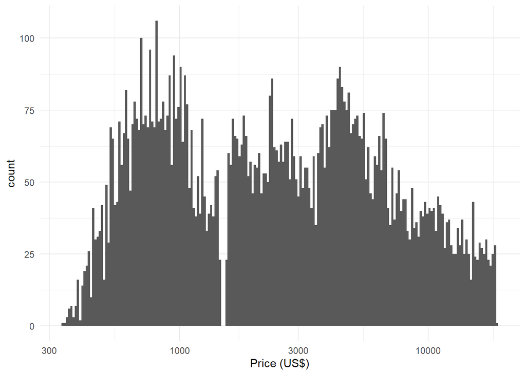

```r
ggplot(diamonds10k, aes(x=price)) +
  geom_histogram(bins=200) +
  scale_x_log10() +
  labs(x="Price (US$)") +
  theme_minimal()
```

Carat:

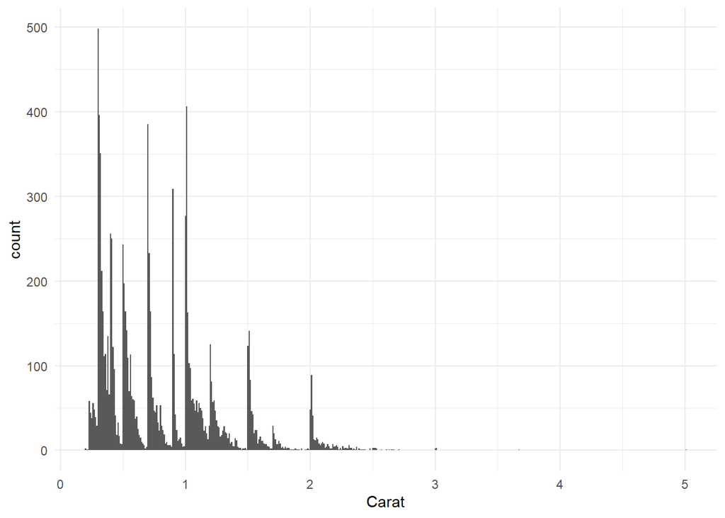

```r
ggplot(diamonds10k, aes(x=carat)) +
  geom_histogram(binwidth=0.01) +
  labs(x="Carat") +
  theme_minimal()
```

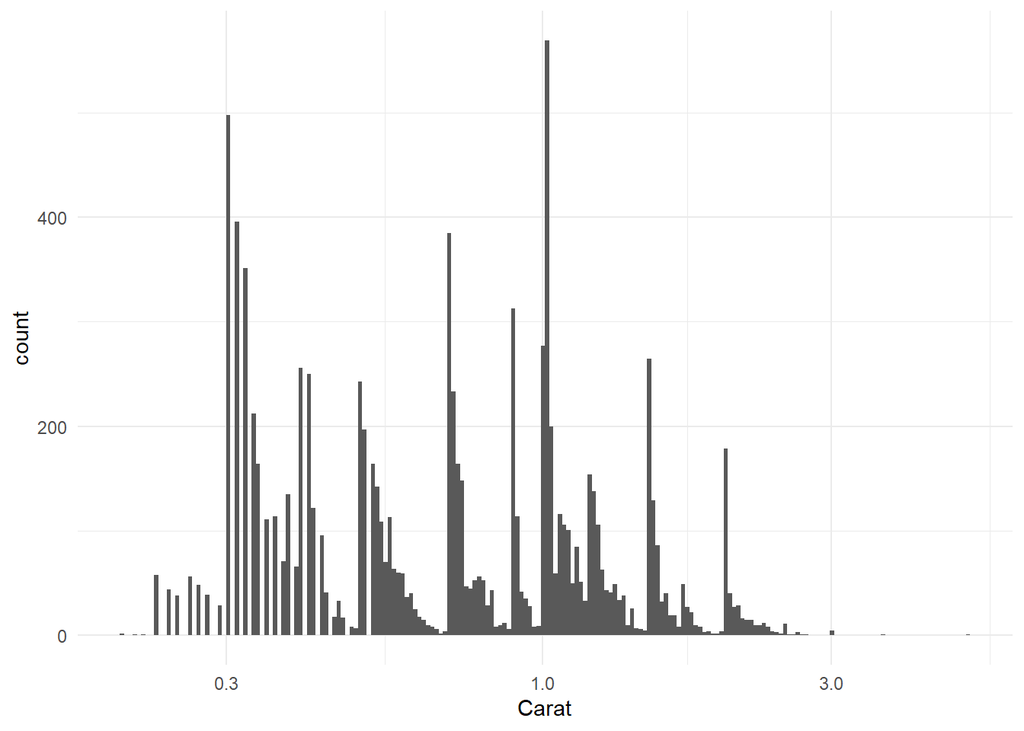

```r
ggplot(diamonds10k, aes(x=carat)) +
  geom_histogram(bins=200) +
  scale_x_log10() +
  labs(x="Carat") +
  theme_minimal()
```

## Fitting the model

We can now fit the model with `lm()`.

```r
fit1 <- lm(log10(price) ~ log10(carat), data=diamonds10k)
summary(fit1)
```

```
##
## Call:
## lm(formula = log10(price) ~ log10(carat), data = diamonds10k)
##
## Residuals:
##      Min       1Q   Median       3Q      Max
## -0.58268 -0.07321 -0.00186  0.07172  0.55150
##
## Coefficients:
##              Estimate Std. Error t value Pr(>|t|)
## (Intercept)  3.667107   0.001393    2633   <2e-16 ***
## log10(carat) 1.673639   0.004536     369   <2e-16 ***
## ---
## Signif. codes:  0 '***' 0.001 '**' 0.01 '*' 0.05 '.' 0.1 ' ' 1
##
## Residual standard error: 0.115 on 9998 degrees of freedom
## Multiple R-squared:  0.9316, Adjusted R-squared:  0.9316
## F-statistic: 1.361e+05 on 1 and 9998 DF,  p-value: < 2.2e-16
```

## Plotting the predictions

To plot the predictions on the original scale, we will need to un-transform the predictions from the model:

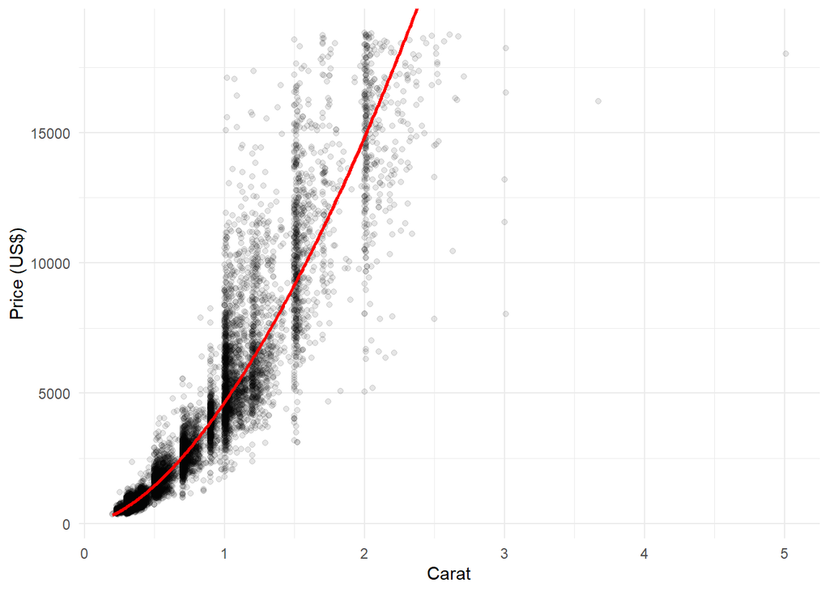

```r
diamonds10k %>%
  add_predictions(fit1, "log10pred") %>%
  mutate(pred = 10^log10pred) %>%
  ggplot(aes(x=carat)) +
  geom_point(aes(y=price), alpha=0.1) +
  geom_line(aes(y=pred), color="red", size=1) +
  coord_cartesian(xlim=range(diamonds10k$carat),
                  ylim=range(diamonds10k$price)) +
  labs(x="Carat", y="Price (US$)") +
  theme_minimal()
```

# Model diagnostics

Plotting the residuals (errors) is a good way of evaluating a model visually and checking for violations of model assumptions.

We expect the true error to be randomly distributed (with a normal distribution for linear models), so plotting the residuals against other variables should show random noise with no systematic pattern.

A systematic pattern when plotted with a variable used in the model indicates a violation of model assumptions.

A systematic pattern when plotted with an unused variables indicates a relationship that your model has not yet adequately captured.

## Plotting the residuals

Look for “simple random scatter”.

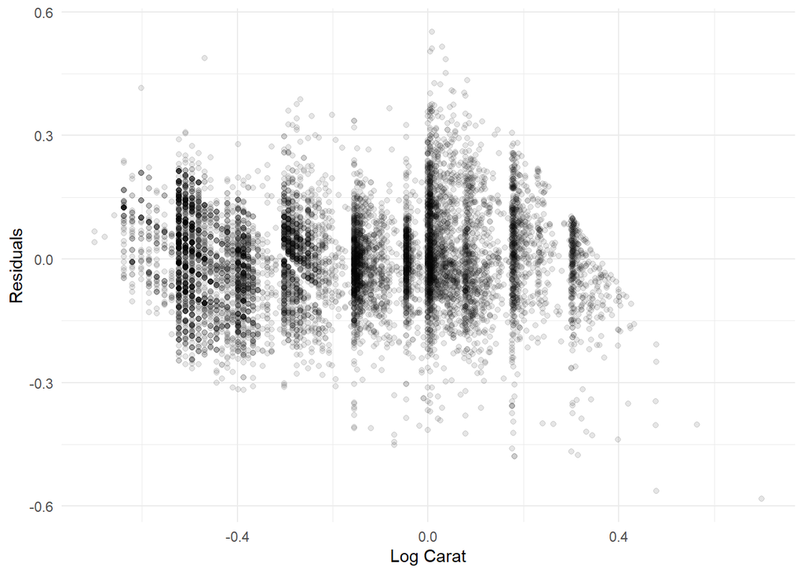

```r
diamonds10k %>%
  add_residuals(fit1, "resid") %>%
  ggplot(aes(x=log10(carat))) +
  geom_point(aes(y=resid), alpha=0.1) +
  labs(x="Log Carat", y="Residuals") +
  theme_minimal()
```

Despite some artifacts, this looks okay.

## Bad residuals

What if we had fit the model on the un-transformed data?

```r
fitbad <- lm(price ~ carat, data=diamonds10k)
```

We see a clear systematic pattern in the residuals:

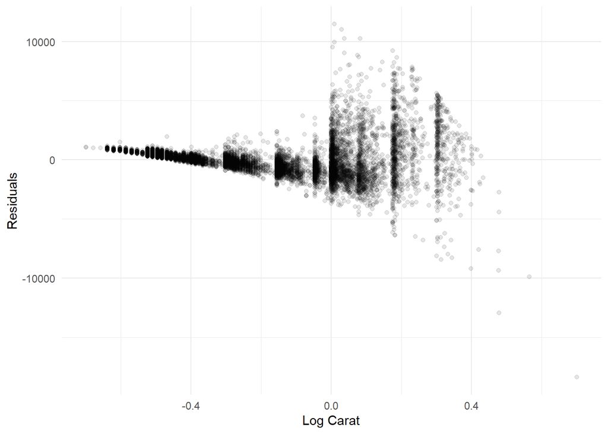

```r
diamonds10k %>%
  add_residuals(fitbad, "resid") %>%
  ggplot(aes(x=log10(carat))) +
  geom_point(aes(y=resid), alpha=0.1) +
  labs(x="Log Carat", y="Residuals") +
  theme_minimal()
```

This indicates a violation of model assumptions (linearity).

## Normality of residuals

We can also check if the residuals are approximately normal.

A qq-plot will be approximately linear if this is the case.

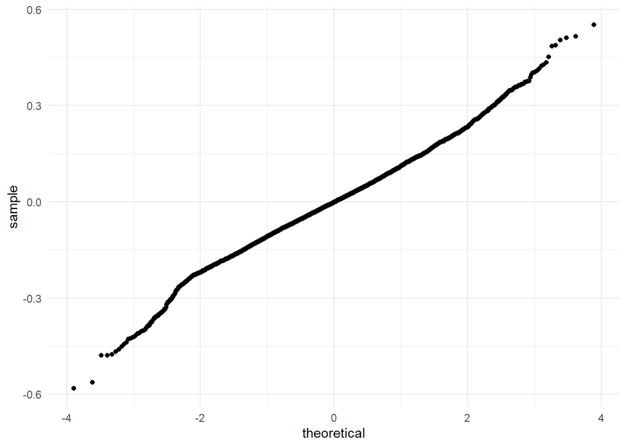

```r
diamonds10k %>%
  add_residuals(fit1, "resid") %>%
  ggplot(aes(sample=resid)) +
  geom_qq() +
  theme_minimal()
```

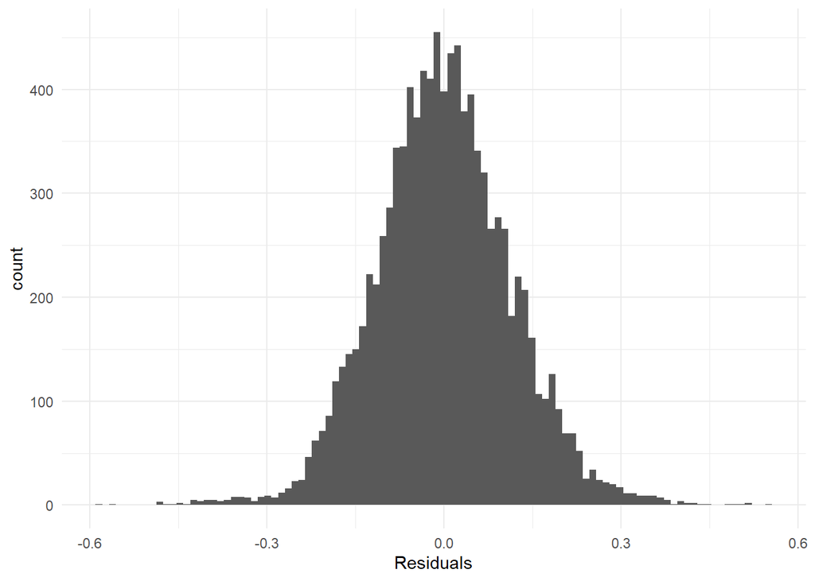

```r
diamonds10k %>%
  add_residuals(fit1, "resid") %>%
  ggplot(aes(x=resid)) +
  geom_histogram(bins=100) +
  labs(x="Residuals") +
  theme_minimal()
```

For the bad model, we see non-normal residuals:

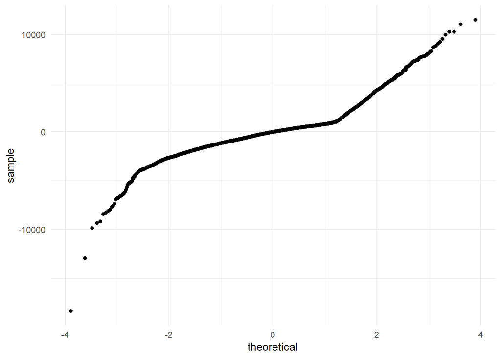

```r
diamonds10k %>%
  add_residuals(fitbad, "resid") %>%
  ggplot(aes(sample=resid)) +
  geom_qq() +
  theme_minimal()
```

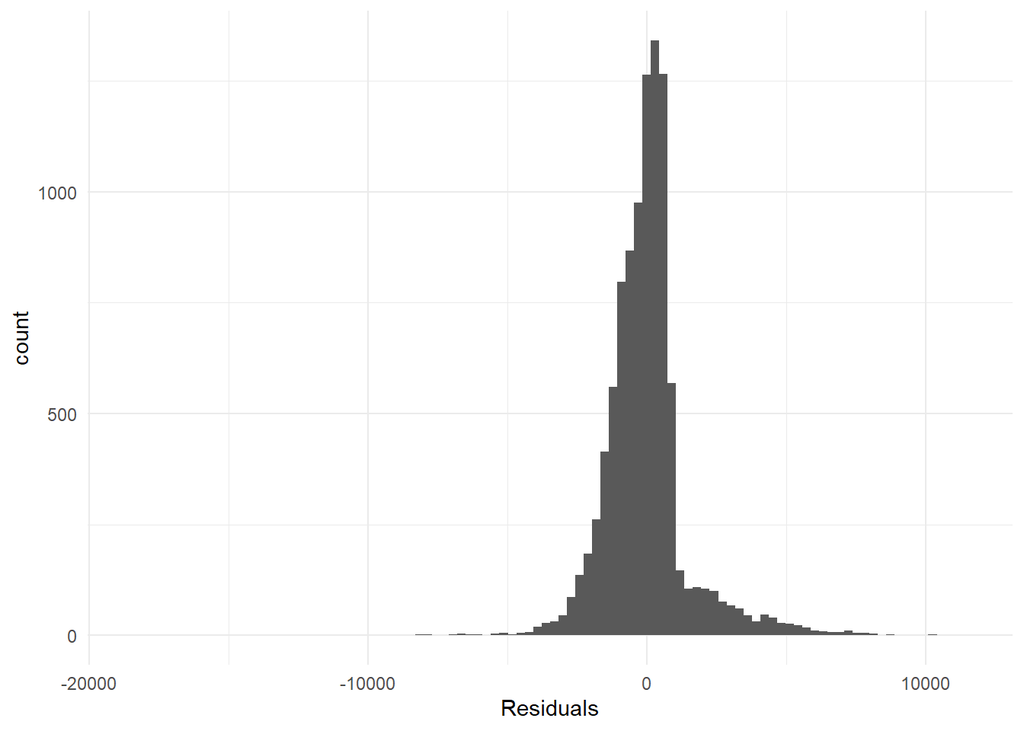

```r
diamonds10k %>%
  add_residuals(fitbad, "resid") %>%
  ggplot(aes(x=resid)) +
  geom_histogram(bins=100) +
  labs(x="Residuals") +
  theme_minimal()
```

## Residuals and candidate predictors

Plotting residuals against other variables not used in the model can reveal additional relationships not yet captured by the model.

The residuals serve as a surrogate variable for the response variable, and show the variation in `price` that hasn’t been captured by the model.

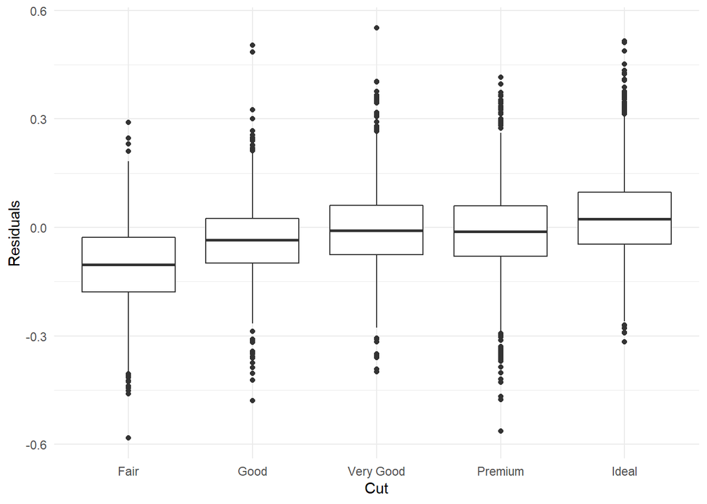

```r
diamonds10k %>%
  add_residuals(fit1, "resid") %>%
  ggplot(aes(x=cut_ord, y=resid)) +
  geom_boxplot() +
  labs(x="Cut", y="Residuals") +
  theme_minimal()
```

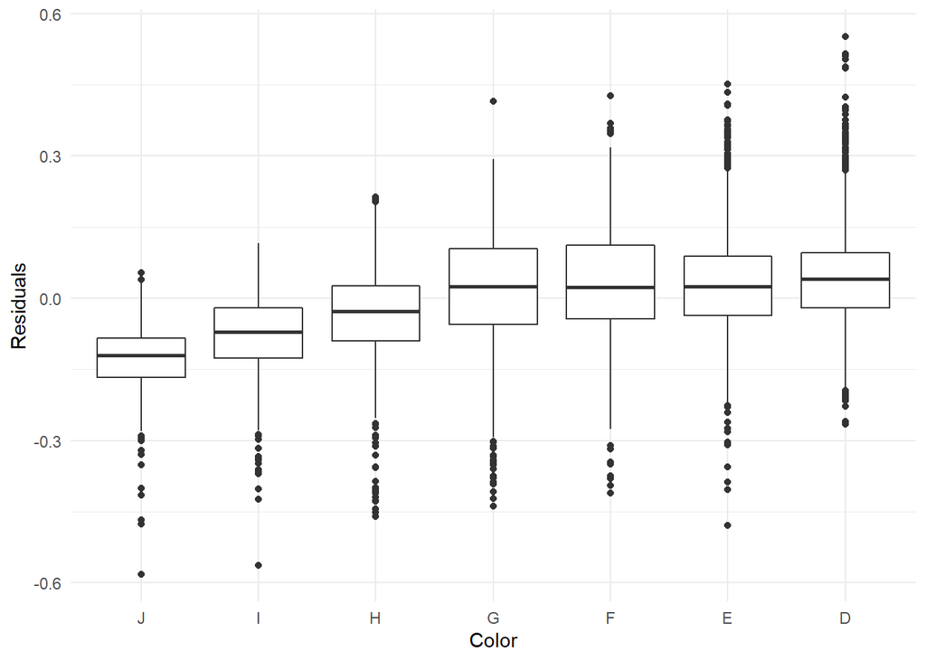

```r
diamonds10k %>%
  add_residuals(fit1, "resid") %>%
  ggplot(aes(x=color_ord, y=resid)) +
  geom_boxplot() +
  labs(x="Color", y="Residuals") +
  theme_minimal()
```

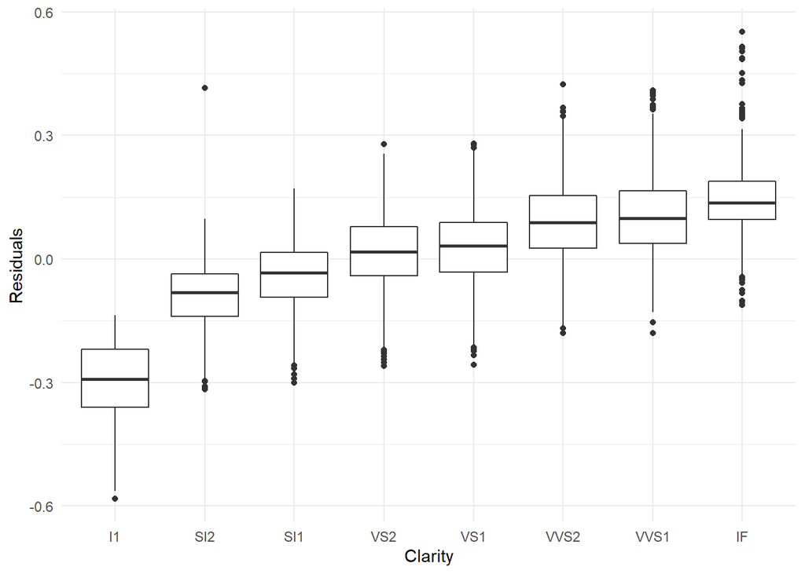

```r
diamonds10k %>%
  add_residuals(fit1, "resid") %>%
  ggplot(aes(x=clarity_ord, y=resid)) +
  geom_boxplot() +
  labs(x="Clarity", y="Residuals") +
  theme_minimal()
```

We can see that by modeling `price` with `carat`, we have removed the variation in `price` that can be explained by `carat`, and the leftover variation shows a sensible relationship with the categorical variables `cut`, `color`, and `clarity`.

## Categorical variables and linear regression

Using categorical variables requires some special care that is handled automatically by R, but must be considered when intepretting model coefficients.

Consider the following simulated data:

```r
sim2
```

```
## # A tibble: 40 x 2
##    x          y
##    <chr>  <dbl>
##  1 a      1.94
##  2 a      1.18
##  3 a      1.24
##  4 a      2.62
##  5 a      1.11
##  6 a      0.866
##  7 a     -0.910
##  8 a      0.721
##  9 a      0.687
## 10 a      2.07
## # ... with 30 more rows
```

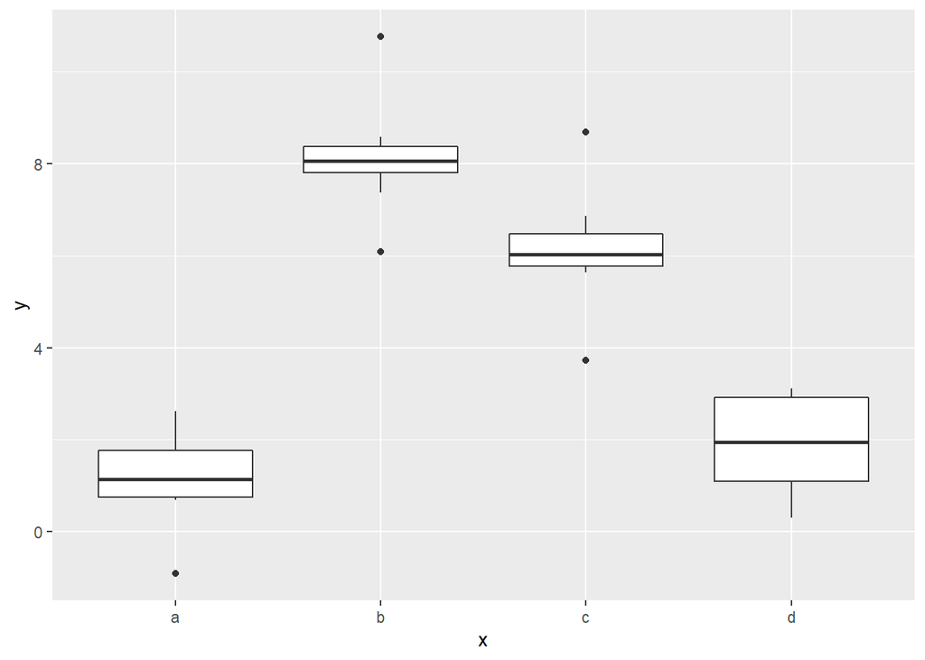

```r
ggplot(sim2, aes(x=x, y=y)) + geom_boxplot()
```

Linear models use indicator variables to model categorical predictors.

Each indicator variable is 0 or 1, where 1 indicates that the value of the categorical variable for that observation is equal to the level of the indicator variable.

```r
model_matrix(sim2, y ~ x)
```

```
## # A tibble: 40 x 4
##    `(Intercept)`    xb    xc    xd
##            <dbl> <dbl> <dbl> <dbl>
##  1             1     0     0     0
##  2             1     0     0     0
##  3             1     0     0     0
##  4             1     0     0     0
##  5             1     0     0     0
##  6             1     0     0     0
##  7             1     0     0     0
##  8             1     0     0     0
##  9             1     0     0     0
## 10             1     0     0     0
## # ... with 30 more rows
```

However, we can’t have both include intercept and also have as many indicators as levels, or the model would be over-parameterized (one column is a perfect linear combination of other columns).

Therefore, one of the levels (usually the first or last, in our case “a”) becomes the reference level and is not included in the indicator variables.

```r
fit <- lm(y ~ x, data=sim2)
fit
```

```
##
## Call:
## lm(formula = y ~ x, data = sim2)
##
## Coefficients:
## (Intercept)           xb           xc           xd
##      1.1522       6.9639       4.9750       0.7588
```

For our dataset `sim2`, why is the level `a` of `x` not included in the model?

It is actually included as the ‘default’ level, so it will correspond to the intercept. We would calculate the predicted values for each level as:

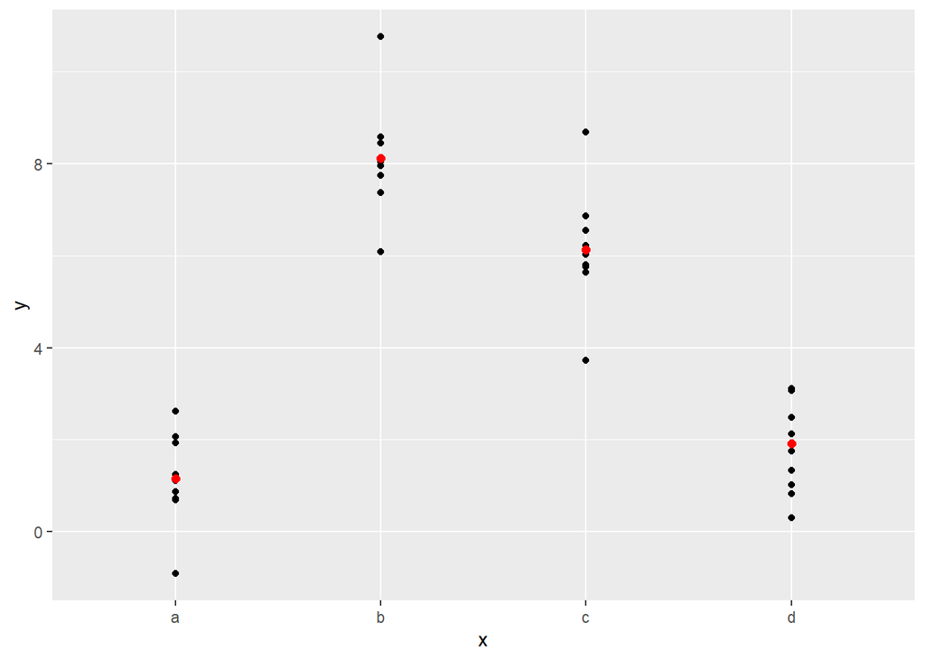

```r
sim2 %>%
  add_predictions(fit) %>%
  ggplot(aes(x=x)) +
  geom_point(aes(y=y)) +
  geom_point(aes(y=pred), col="red", size=2)
```

# Fitting a new model

```r
fit2 <- lm(log10(price) ~ log10(carat) + cut + color + clarity, data=diamonds10k)
summary(fit2)
```

```
##
## Call:
## lm(formula = log10(price) ~ log10(carat) + cut + color + clarity,
##     data = diamonds10k)
##
## Residuals:
##      Min       1Q   Median       3Q      Max
## -0.30130 -0.03785  0.00030  0.03564  0.61635
##
## Coefficients:
##               Estimate Std. Error t value Pr(>|t|)
## (Intercept)   3.406711   0.005657 602.249   <2e-16 ***
## log10(carat)  1.885043   0.002622 719.022   <2e-16 ***
## cutGood       0.032996   0.003916   8.425   <2e-16 ***
## cutIdeal      0.068733   0.003574  19.233   <2e-16 ***
## cutPremium    0.061333   0.003600  17.039   <2e-16 ***
## cutVery Good  0.051455   0.003637  14.147   <2e-16 ***
## colorE       -0.025128   0.002143 -11.725   <2e-16 ***
## colorF       -0.042578   0.002166 -19.662   <2e-16 ***
## colorG       -0.069469   0.002119 -32.779   <2e-16 ***
## colorH       -0.109174   0.002217 -49.246   <2e-16 ***
## colorI       -0.163604   0.002514 -65.090   <2e-16 ***
## colorJ       -0.218540   0.003084 -70.872   <2e-16 ***
## clarityIF     0.494152   0.005840  84.617   <2e-16 ***
## claritySI1    0.263421   0.004922  53.519   <2e-16 ***
## claritySI2    0.194070   0.004948  39.221   <2e-16 ***
## clarityVS1    0.358632   0.005048  71.040   <2e-16 ***
## clarityVS2    0.326656   0.004952  65.967   <2e-16 ***
## clarityVVS1   0.450899   0.005372  83.936   <2e-16 ***
## clarityVVS2   0.420432   0.005195  80.931   <2e-16 ***
## ---
## Signif. codes:  0 '***' 0.001 '**' 0.01 '*' 0.05 '.' 0.1 ' ' 1
##
## Residual standard error: 0.05791 on 9981 degrees of freedom
## Multiple R-squared:  0.9827, Adjusted R-squared:  0.9827
## F-statistic: 3.148e+04 on 18 and 9981 DF,  p-value: < 2.2e-16
```